# Chapter 9 Problems 19 & 31

Bri Bentley

Apr 18, 2018

**19. The director of urban housing in the Vitoria, Spain claims that at least 50% of all apartments have more than one bathroom and that at least 75% of all apartments have an elevator.**

```r
library(PASWR2)
summary(VIT2005)
```

```
##    totalprice          area             zone     category      age
##  Min.   :155000   Min.   : 50.38   Z41    : 18   2A: 4    Min.   :  1.0
##  1st Qu.:228500   1st Qu.: 75.18   Z53    : 16   2B:14    1st Qu.: 11.0
##  Median :269750   Median : 86.39   Z52    : 15   3A:61    Median : 16.0
##  Mean   :280742   Mean   : 88.70   Z61    : 14   3B:77    Mean   : 19.9
##  3rd Qu.:328625   3rd Qu.: 99.90   Z62    : 14   4A:36    3rd Qu.: 24.0
##  Max.   :560000   Max.   :187.91   Z45    : 13   4B:23    Max.   :118.0
##                                    (Other):128   5A: 3
##      floor           rooms         out      conservation    toilets
##  Min.   : 1.00   Min.   :3.000   E100:122   1A:161       Min.   :1.000
##  1st Qu.: 3.00   1st Qu.:5.000   E25 :  3   2A: 18       1st Qu.:1.000
##  Median : 4.00   Median :5.000   E50 : 87   2B: 36       Median :1.000
##  Mean   : 4.44   Mean   :4.853   E75 :  6   3A:  3       Mean   :1.468
##  3rd Qu.: 5.00   3rd Qu.:5.000                           3rd Qu.:2.000
##  Max.   :12.00   Max.   :7.000                           Max.   :2.000
##
##      garage          elevator      streetcategory heating
##  Min.   :0.0000   Min.   :0.0000   S2: 42         1A:  8
##  1st Qu.:0.0000   1st Qu.:1.0000   S3:107         3A:149
##  Median :0.0000   Median :1.0000   S4: 59         3B: 10
##  Mean   :0.2431   Mean   :0.7982   S5: 10         4A: 51
##  3rd Qu.:0.0000   3rd Qu.:1.0000
##  Max.   :2.0000   Max.   :1.0000
##
##     storage
##  Min.   :0.0000
##  1st Qu.:1.0000
##  Median :1.0000
##  Mean   :0.8073
##  3rd Qu.:1.0000
##  Max.   :2.0000
##
```

```r
head(VIT2005)
```

```
##   totalprice   area zone category age floor rooms  out conservation
## 1     228000  75.31  Z45       4B  33     3     5 E100           2B
## 2     409000 100.65  Z31       3B   5     7     5  E50           1A
## 3     200000  88.87  Z52       3A  14     8     5  E50           1A
## 4     180000  62.61  Z62       4A  41     3     4  E50           2A
## 5     443600 146.15  Z31       3A  22     6     7 E100           1A
## 6     173000  77.21  Z11       4B  35     4     5  E50           1A
##   toilets garage elevator streetcategory heating storage
## 1       1      0        1             S3      3A       0
## 2       2      1        1             S5      4A       1
## 3       2      0        1             S2      3A       0
## 4       1      0        0             S3      1A       0
## 5       2      0        1             S4      4A       1
## 6       1      0        0             S4      3A       1
```

1. Can the director’s claim about bathrooms be contradicted? Test the appropriate hypothesis using $\alpha = 0.10$. Note that the number of bathrooms is stored in the variable `toilets` in the data frame `VIT2005`.

   $H_0: p = 0.50$ versus $H_1: p < 0.50$

```r
#Test statistic is the number of aparments that have more than one bathroom
xtabs(~toilets, data = VIT2005)
```

```
## toilets
##   1   2
## 116 102
```

Therefore, the value of the test statistic is 102 out of 218.

```r
#Finding the p-vlaue
binom.test(x = 102, n = 218, p = 0.50, alternative = "less")
```

```
##
##  Exact binomial test
##
## data:  102 and 218
## number of successes = 102, number of trials = 218, p-value =
## 0.1893
## alternative hypothesis: true probability of success is less than 0.5
## 95 percent confidence interval:
##  0.000000 0.525842
## sample estimates:
## probability of success
##              0.4678899
```

Thus we fail to reject the null hypothesis because 0.1893 > 0.10.

2. Can the director’s claim about elevators be substantiated using an $\alpha = 0.10$? Use both an approximate method as well as an exact method to reach a conclusion. Are the methods in agreement?
- Exact Method:

  $H_0: p = 0.75$ versus $H_1: p > 0.75$

```r
#Test statistic is the number of apartments that have more than one elevator
xtabs(~elevator, data = VIT2005)
```

```
## elevator
##   0   1
##  44 174
```

Therefore, the value of the test statistic is 174 out of out of 218.

```r
#Finding the p-value
binom.test(x = 174, n = 218, p = 0.75, alternative = "greater")
```

```
##
##  Exact binomial test
##
## data:  174 and 218
## number of successes = 174, number of trials = 218, p-value =
## 0.05643
## alternative hypothesis: true probability of success is greater than 0.75
## 95 percent confidence interval:
##  0.748218 1.000000
## sample estimates:
## probability of success
##              0.7981651
```

Thus we reject the null in favor of the alternative because 0.05643 < 0.10.

English Conclusion: There is evidence to support the claim that at least 75% of apartments have an elevator.

- Approximate Method:

  $H_0: p = 0.75$ versus $H_1: p > 0.75$

```r
#Without continuity correction
prop.test(x = 174, n = 218, p = 0.75, alternative = "greater", correct = FALSE)
```

```
##
##  1-sample proportions test without continuity correction
##
## data:  174 out of 218, null probability 0.75
## X-squared = 2.6972, df = 1, p-value = 0.05026
## alternative hypothesis: true p is greater than 0.75
## 95 percent confidence interval:
##  0.7499209 1.0000000
## sample estimates:
##         p
## 0.7981651
```

```r
#with continuity correction
prop.test(x = 174, n = 218, p = 0.75, alternative = "greater", correct = TRUE)
```

```
##
##  1-sample proportions test with continuity correction
##
## data:  174 out of 218, null probability 0.75
## X-squared = 2.4465, df = 1, p-value = 0.05889
## alternative hypothesis: true p is greater than 0.75
## 95 percent confidence interval:
##  0.7474708 1.0000000
## sample estimates:
##         p
## 0.7981651
```

Thus we reject the null in favor of the alternative because the p-value without continuity correction, 0.05026, or the p-value with continuity correction, 0.05889, is less than our significance level of 0.10.

English Conclusion: There is evidence to support the claim that at least 75% of apartments have an elevator.

Using both methods, we rejected the null in favor of the alternative so the methods are in agreement.

3. Test whether the proportion of apartments built prior to 1980 without garages have a smaller proportion with elevators than without elevators.

```r
#Subset the data, note that we want when the age > 25 because 2005 - 1980 is 25 so that will give us all the data prior to 1980
Apartments <- xtabs(~elevator + garage, data = subset(VIT2005, subset = age > 25))
Apartments
```

```
##         garage
## elevator  0  1
##        0 19  0
##        1 22  4
```

Thus 19 apartments without garages did not have an elevator and 22 apartments without garages did have an elevator. There were a total of 45 apartments sampled prior to 1980.

```r
fisher.test(Apartments, alternative = "greater")
```

```
##
##  Fisher's Exact Test for Count Data
##
## data:  Apartments
## p-value = 0.1003
## alternative hypothesis: true odds ratio is greater than 1
## 95 percent confidence interval:
##  0.6878007       Inf
## sample estimates:
## odds ratio
##        Inf
```

Therefore we fail to reject the null since 0.1003 > 0.10.

English Conclusion: There is no significant evidence that the proportion of apartments built prior to 1980 with elevators and no garages is lower than the proportion of apartments built prior to 1980 without elevators and no garages.

**31. Cleveland (1993) suggested that the yeild recorded for the year 1932 was actually 1931’s yield and vice versa for the Morris site in the** `barley` **data set after examining the data using trellis graphics.**

```r
summary(barley)
```

```
##      yield            variety     year                 site
##  Min.   :14.43   Svansota :12   1932:60   Grand Rapids   :20
##  1st Qu.:26.88   No. 462  :12   1931:60   Duluth         :20
##  Median :32.87   Manchuria:12             University Farm:20
##  Mean   :34.42   No. 475  :12             Morris         :20
##  3rd Qu.:41.40   Velvet   :12             Crookston      :20
##  Max.   :65.77   Peatland :12             Waseca         :20
##                  (Other)  :48
```

```r
head(barley)
```

```
##      yield   variety year            site
## 1 27.00000 Manchuria 1931 University Farm
## 2 48.86667 Manchuria 1931          Waseca
## 3 27.43334 Manchuria 1931          Morris
## 4 39.93333 Manchuria 1931       Crookston
## 5 32.96667 Manchuria 1931    Grand Rapids
## 6 28.96667 Manchuria 1931          Duluth
```

1. Use the package lattice to recreate the trellis graph that would have given Cleveland his insight. Change the default layout so the graph has two columns and three rows of plots.

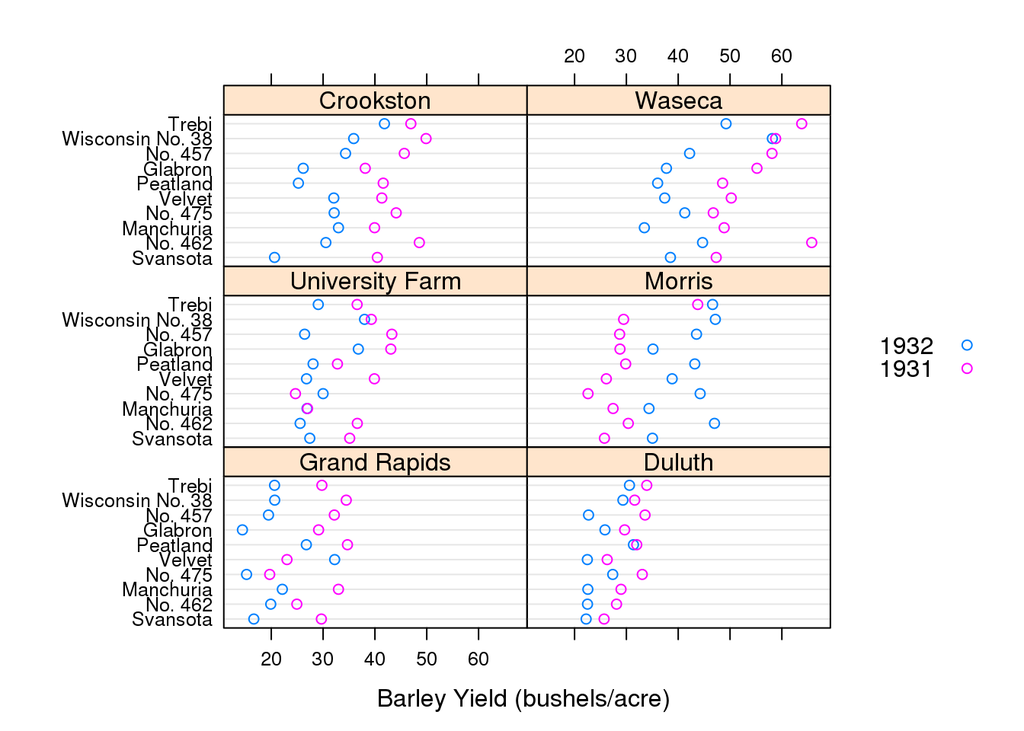

```r
library(lattice)
dotplot(variety ~ yield | site, data = barley, groups = year,
        key = simpleKey(levels(barley$year), space = "right"),
        xlab = "Barley Yield (bushels/acre) ", aspect = 0.5, layout = c(2,3), ylab=NULL)
```

2. Recreate the graph from (A) using `ggplot2`.

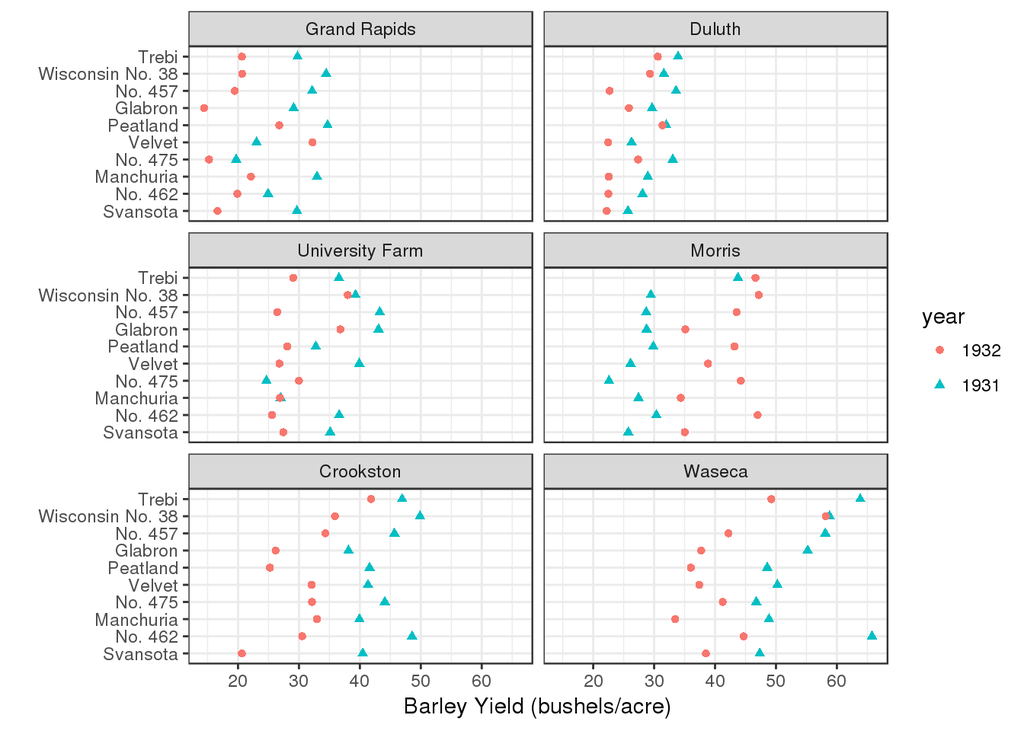

```r
library(ggplot2)
ggplot(data = barley, aes(yield, variety, color = year, shape = year)) +
  geom_point() +
  theme_bw() +
  facet_wrap(~site, ncol = 2) +
  labs(x = "Barley Yield (bushels/acre)", y = "")
```

3. If the years were actually switched as described when the data was originally recorded, is there evidence to suggest the average barley yield in 1932 (recorded as 1931’s yield) for the Morris site is greater than the average barley yield in 1932 for the Crookston site? Use the 5-step procedure to test the appropriate hypotheses using an $\alpha = 0.05$ significance level.

```r
Morris <- with(data = barley, yield[year == "1931" & site == "Morris"])
Crookston <- with(data = barley, yield[year == "1932" & site == "Crookston"])
Morris
```

```
##  [1] 27.43334 28.76667 25.76667 26.13333 43.76667 28.70000 30.36667
##  [8] 29.86667 22.60000 29.46667
```

```r
Crookston
```

```
##  [1] 32.96667 26.16667 20.63333 32.06666 41.83333 34.33333 30.53333
##  [8] 25.23333 32.13333 35.90000
```

- Step 1: Hypotheses

  $H_0: \mu = 0$ versus $H_1: \mu > 0$
- Step 2: Test Statistic

```r
Difference <- Morris - Crookston
meandif <- mean(Difference)
meandif
```

```
## [1] -1.893329
```

- Step 3: Rejection Region Calculations

```r
RR <- qt(0.95, 9)
RR
```

```
## [1] 1.833113
```

```r
t.test(Difference, alternative = "greater")
```

```
##
##  One Sample t-test
##
## data:  Difference
## t = -1.1307, df = 9, p-value = 0.8563
## alternative hypothesis: true mean is greater than 0
## 95 percent confidence interval:
##  -4.962699       Inf
## sample estimates:
## mean of x
## -1.893329
```

The value of the standardized test statistic is -1.1307

- Step 4: Statistical Conclusion

Given the rejection region, we fail to reject the null because -1.1307 < 1.8331. Also given the p-value, we fail to reject the null because 0.8563 > 0.05

- Step 5: English Conclusion

There is no significant evidence that shows the 1932 mean barley yield for Morris is greater than the 1932 mean barley yield for Crookston.